# MATH 495 - Project #1

### 4.2

It is often conjectured that marijuana is a “gateway drug” in the sense that it is used as a first illegal substance for many individuals who end up using other substances. With this background interest in mind, we attempt to build a classifier for whether an individual has ever used any drugs *other than* cannabis. The set of potential predictors are the 16 personal traits and non illegal substances used in questions 2 and 3, along with *cannabis* We first define our variable of interest:

```r
druguse$allelse = apply(druguse[,c(17:19, 21:31)],1,sum)
druguse$allelse = factor(ifelse(druguse$allelse>0, "yes", "no"))
full = druguse[,c(1:16,20,ncol(druguse))]
```

We are interested in determining whether *cannabis* is a significant predictor when adjusting for all other potential predictors, so we attempt to find the “best” model INCLUDING *cannabis* as a predictor, and the “best” model EXCLUDING it as a predictor, and compare the accuracy of these two models using cross validation. We are approaching the problem similarly to one of ANOVA, except the models are not necessarily nested and we are relying on prediction accuracy as our main criterion and not maximum likelihood theory.

The definition of “best” will be the one provided by stepwise regression, as was detailed in question 1. We select two models as follows based on the Akaike Information Criterion (I also performed the following using BIC, but prediction errors were higher - we allow the reader to change k=log(nrow(full)) if they desire to see this):

```r
k = 2
null_excl = glm(allelse~1, family=binomial(link="logit"), data=full[,-17])
full_excl = glm(allelse~., family=binomial(link="logit"), data=full[,-17])
AICmod_excl = step(null_excl, scope = list(lower=null_excl, upper=full_excl), direction="both", k=k, trace=FALSE)
#extract variable names for model excluding cannabis
AICmodvars_excl = all.vars(AICmod_excl$formula)
AICmod_excl$formula
```

```
## allelse ~ nicotine + country + sensation + conscientiousness +
##     opentoexperience + extraversion + gender + ethnicity + agegroup +
##     impulsiveness + agreeableness
```

```r
null_incl = glm(allelse~cannabis, family=binomial(link="logit"), data=full)
full_incl = glm(allelse~., family=binomial(link="logit"), data=full)
AICmod_incl = step(null_incl, scope = list(lower=null_incl, upper=full_incl), direction="both", k=k, trace=FALSE)
#extract variable names for model excluding cannabis
AICmodvars_incl = all.vars(AICmod_incl$formula)
AICmod_incl$formula
```

```
## allelse ~ cannabis + conscientiousness + nicotine + agegroup +
##     country + impulsiveness + opentoexperience + extraversion
```

Note the formulas indicating which variables are included in each. We also note that excluding the feature selection from the cross validation procedure will optimistically bias the estimate of the error found below, it is reasonable to assume that our conclusion regarding *cannabis* will be unaffected (and this may also produce a good final model regardless). We compare the two models below:

```r
set.seed(123)
permutation_inds = sample(nrow(full))
model_inc_err = NULL
model_excl_err = NULL
model_inc_df = full[,AICmodvars_incl]
model_excl_df = full[,AICmodvars_excl]

for (i in 1:10){
  inds = (188*(i-1)+1):(188*i)
  if (i ==10){
    inds = (188*(i-1)+1):1885
  }

  train_incl = model_inc_df[permutation_inds[-inds],]
  test_incl = model_inc_df[permutation_inds[inds],]

  train_excl = model_excl_df[permutation_inds[-inds],]
  test_excl = model_excl_df[permutation_inds[inds],]

  modincl = rpart(allelse ~., data=train_incl)
      #modincl = glm(allelse ~., data=train_incl, family=binomial(link="logit"))
  predsincl = predict(modincl, newdata = test_incl, type="class")
      #predsincl = ifelse(predict(modincl, test_incl, type = "response")>.5, "yes", "no")
  errincl = sum(predsincl != test_incl$allelse)/nrow(test_incl)
  model_inc_err = c(model_inc_err, errincl)

  modexcl = rpart(allelse ~., data=train_excl)
      #modexcl = glm(allelse ~., data=train_excl, family=binomial(link="logit"))
  predsexcl = predict(modexcl, newdata = test_excl, type="class")
      #predsexcl = ifelse(predict(modexcl, test_excl, type = "response")>.5, "yes", "no")
  errexcl = sum(predsexcl != test_excl$allelse)/nrow(test_excl)
  model_excl_err = c(model_excl_err, errexcl)

}

#Error rate from excluding cannabis:
mean(model_excl_err)
```

```
## [1] 0.1867655
```

```r
#Error rate from including cannabis:
mean(model_inc_err)
```

```
## [1] 0.1304652
```

The error rates for other models can be found simply by replacing *rpart* with *glm* or *randomForest* and I list them below:

1. AIC, logistic regression : $0.1624$ excluding, $0.1326$ including
2. AIC, random forest: $0.167$ excluding, $0.1405$ including
3. BIC, decision tree: $0.184$ excluding, $0.1310$ including
4. BIC, logistic regression: $0.162$ excluding, $0.144$ including
5. BIC, random forest: $0.178$ excluding, $0.149$ including

For the reason of optimizing estimated test error, we choose a DECISION TREE including *cannabis* with the following call:

```r
AICmod_incl$formula
```

```
## allelse ~ cannabis + conscientiousness + nicotine + agegroup +
##     country + impulsiveness + opentoexperience + extraversion
```

```r
finalmod = rpart(AICmod_incl$formula, data = model_inc_df)
```

The above output indicates that this model performs better than all of the others listed, with an estimated accuracy of $86.95\%$. Below is its plot to indicate the decisions graphically:

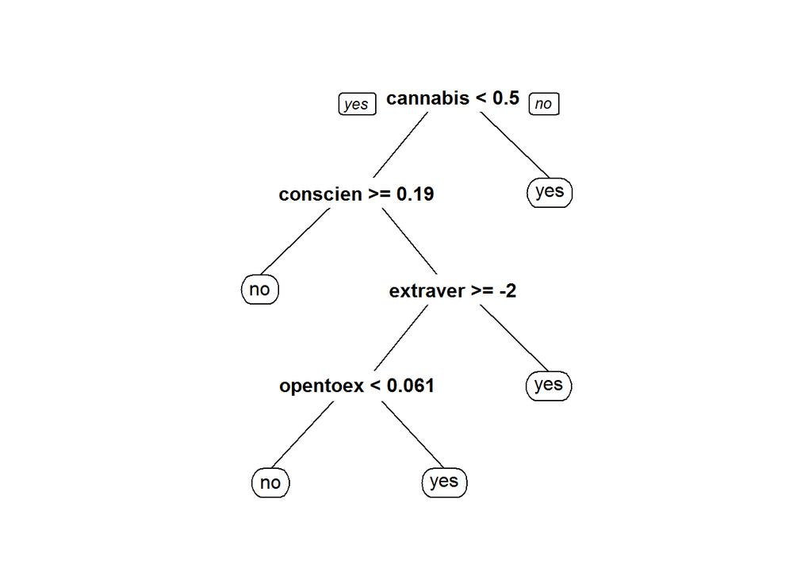

```r
rpart.plot.version1(finalmod)
```

Finally, we address the estimate of the loss. We have used the typical loss function $\frac{1}{n^*}I(y_{pred} \ne y_{obs})$, where $n^* =$ number of predictions. Our estimate of the loss is given by the estimated cross validation error of $13.04\%$.

## Mathematical Notes

### (1)

I address our implementation of naive Bayes in question 3 because we did not discuss the following in class. We proceeded as follows: Let $Y =$ *UseLevel* and $X = (x_1,...,x_p)^T$ be our vector of covariates. For each test observation, we classify $Y$ to $y_k \in \{$*high*,*low*$\}$ if the following is maximized:

$$\prod_{i=1}^p\hat{P}(x_i |y_{obs})\hat{P}(Y=y_{obs}) \propto\hat{P}(Y=y_k|X)$$
For categorical data, this procedure is the same as in class with $\hat{P}$ equal to the population proprotions in all cases. However, with the continuous variables in our dataset, we have set $\hat{P}(x_i|y_k) = \phi(\mu_{y_k}, \sigma_{y_k})$, where $\phi$ is a Gaussian density and $\mu, \sigma$ are the conditional sample means for $x_i$ in the $y_k$ category.

### (2)

In computing our distances between points in k-nearest-neighbours in question 3, an alternative method could have been to add a discrete metric (for $x, y$ categorical observations $d(x,y) = \delta > 0$ if $x\ne y$, $d(x,y) = 0$ if $x = y$), instead of encoding to numeric and using the overall Euclidean metric on the data. This may make more sense for categorical variables that are not ordinal.

## Informal Citations

https://machinelearningmastery.com/feature-selection-with-the-caret-r-package/

Our course webpage and practicals on Canvas